# WeRateDogs

## WeRateDogs Data

WeRateDogs

WeRateDogs is a Twitter account that rates dog pictures using pretty unorthodox scale in which more often than not actual rating exceeds standard denominator of 10, with justification of such tomfoolery being "they're good dogs Brent" along with funny comments.

However, this comedy account is not only a good source for your daily dose of humorous tweets, but with 4 million followers and 5000+ tweets, it is a solid database for curios minds in search for answers to dog related questions. For example, if you are prospective dog owner, the questions, such as “what is the most likable breed of dogs?”, “what is the most popular one?” , and “what is the most popular dog name?” may arise.

However, before jumping into answering these questions, let’s try to find out more about WeRateDogs twitter account itself. Luckily, we have some data, which may help us understand some user habits - what are the hours of increased account activity, what is the preferable platform and how many words per tweet it usually takes to provide chuckleworthy comment.

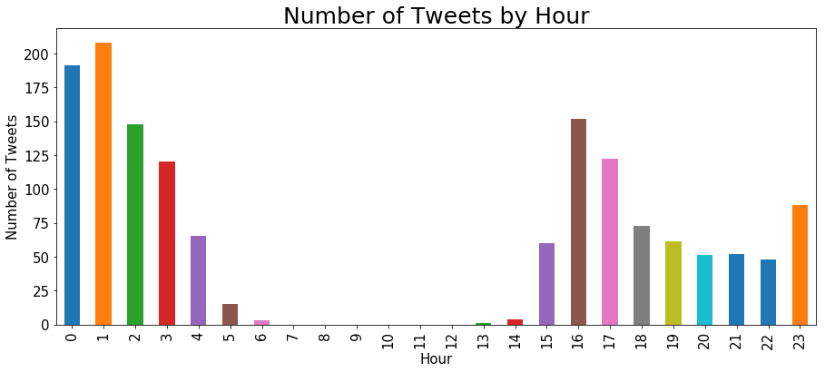

We can see that there are two spikes in account activity throughout the day - around 1am and 4pm, with most tweets being posted between 3pm and 4am (most likely there is a time zone difference issue).

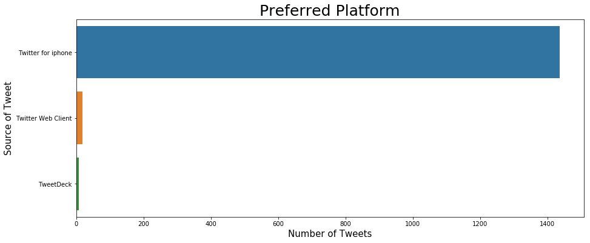

Whomever runs this account sure loves Iphone since this is the platform that has been used almost exclusively to post tweets.

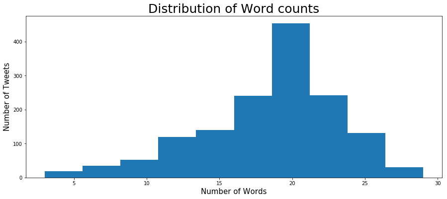

They say that brevity is the soul of wit, and judging from the fact that it usually takes around 20 words per tweet, I am inclined to agree with this statement.

Now that we got to know WeRateDogs a little better, let's try to tackle some dog related question, starting with the one of the most obvious - what is the most popular dog breed?

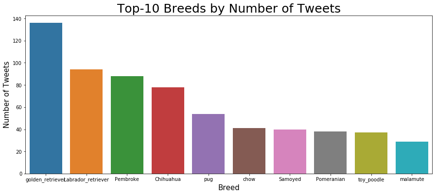

The graph above have confirmed my suspicion that the winner of popularity contest is golden retriever, but is it the highest rated one?

Let's find out by looking at chart showing how many times tweet related to specific breed was chosen by user as favorite.

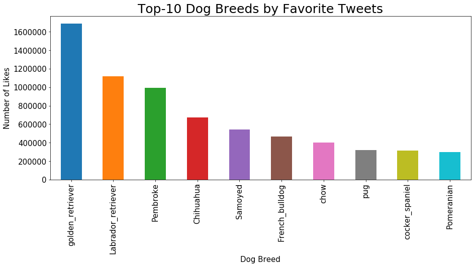

Again, it seems that tweets related to golden retriever are the most liked ones. However, it may be due to the larger pool of tweets about golden retrievers, so, it would make sense to check average rating by WeRateDogs for each breed.

In order to eliminate outliers and one-hit-wonders of the dog World, we will consider only breeds with at least 5 entries.

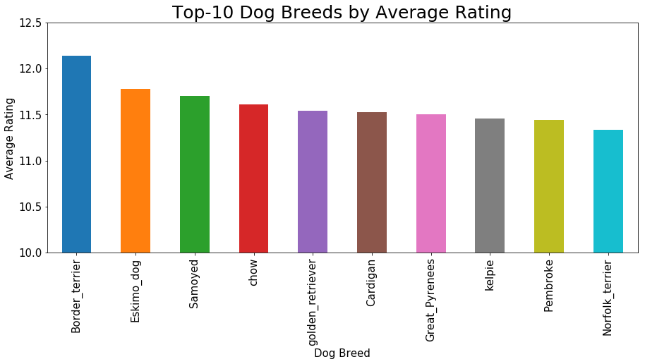

The results above show that border terrier has the highest average rating, but golden retrievers have also made it to Top-5.

Finally, let's see what are the most popular dog names in our dataset.

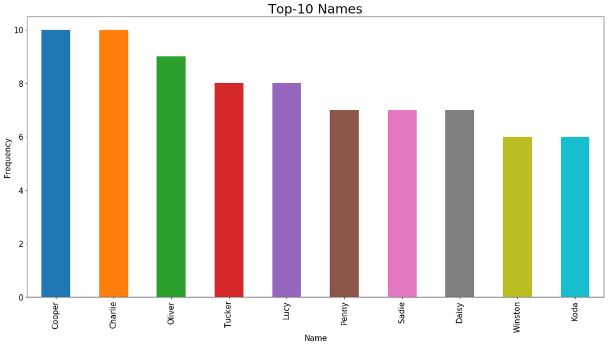

"Cooper" and "Charlie" those are pet names in high demand right now.